# Gender Wage Gap Decomposition: Philippine LFS 2004–2024

AJ Montesa

2026-02-20

> **Sign convention used throughout this document:** All gap measures are computed as **(Female − Male)**, so that **positive values = women earn more** and **negative values = men earn more**. This applies to raw gaps, log gaps, OLS coefficients, and OB decomposition components.

# Data Preparation

```r
cpi_quarterly <- read_csv("../Data/cpi_quarterly.csv")
lfs_harmonized <- read_rds("../Data/lfs_harmonized_2004_2025Q2.rds")

lfs_analysis <- lfs_harmonized %>%
  filter(
    class_label %in% c("Private Establishment", "Government/GOCC", "Private Household"),
    !is.na(basic_pay_php) & basic_pay_php > 0,
    age_years >= 15 & age_years <= 64,
    !is.na(sex_label), !is.na(educ_5cat_label), !is.na(occ_label),
    !is.na(ind_label), !is.na(hours_primary_num), !is.na(region),
    year <= 2024
  ) %>%
  mutate(qtr = as.Date(str_c(year, "-", str_pad((quarter*3)-2, 2, "left", "0"), "-01"))) %>%
  left_join(cpi_quarterly) %>%
  mutate(
    real_basic_pay_php = basic_pay_php * (100 / CPI),
    ln_wage = log(real_basic_pay_php),
    female = case_when(
      sex_label %in% c("Female", "F", 2) ~ 1L,
      sex_label %in% c("Male", "M", 1) ~ 0L,
      TRUE ~ NA_integer_
    ),
    educ     = fct_reorder(educ_5cat_label, educ_5cat),
    occup    = factor(occ_label),
    class_worker = factor(class_label),
    age_sq   = age_years^2,
    marital  = factor(marital_harmonized, levels = c("Single","Married","Divorced/Separated","Widowed")),
    region   = case_when(region == "04" ~ "41", region == "17" ~ "42", region == "19" ~ "15", TRUE ~ region),
    region_cat = factor(region, levels = c("13","14","01","02","03","41","42","05",
                                           "06","07","18","08","09","10","11","12","15","16")),
    year_factor = factor(year),
    period = factor(case_when(
      year <= 2008 ~ "2004-2008", year <= 2013 ~ "2009-2013",
      year <= 2018 ~ "2014-2018", TRUE ~ "2019-2024"
    ), levels = c("2004-2008","2009-2013","2014-2018","2019-2024"))
  )
```

```r
lfs_analysis %>% count(year, sex_label) %>% pivot_wider(names_from = sex_label, values_from = n)
```

```
## # A tibble: 21 × 3
##     year Female  Male
##    <int>  <int> <int>
##  1  2004  52804 88286
##  2  2005  50955 79328
##  3  2006  50439 77697
##  4  2007  51445 79247
##  5  2008  50554 78047
##  6  2009  52369 80288
##  7  2010  53691 82637
##  8  2011  55340 85606
##  9  2012  57080 88940
## 10  2013  58240 91961
## # ℹ 11 more rows
```

# Phase 1: Unweighted Mean Gap

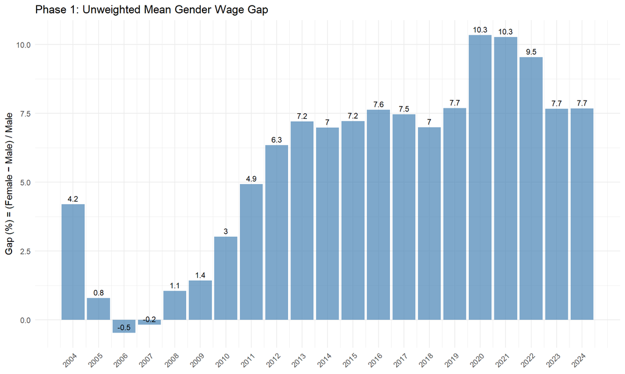

```r
phase1 <- lfs_analysis %>%
  group_by(year, sex_label) %>%
  summarize(mean_wage = mean(real_basic_pay_php)) %>%
  pivot_wider(names_from = sex_label, values_from = mean_wage) %>%
  mutate(gap_php = Female - Male,
         gap_pct = (Female - Male) / Male * 100)

ggplot(phase1, aes(x = year)) +
  geom_col(aes(y = gap_pct), fill = "steelblue", alpha = 0.7) +
  geom_text(aes(y = gap_pct, label = round(gap_pct, 1)), vjust = -0.5, size = 3) +
  labs(x = NULL, y = "Gap (%) = (Female − Male) / Male",
       title = "Phase 1: Unweighted Mean Gender Wage Gap") +
  scale_x_continuous(breaks = 2004:2024) +
  theme_minimal() +
  theme(axis.text.x = element_text(angle = 45, hjust = 1))
```

# Phase 2: Does Weighting Matter?

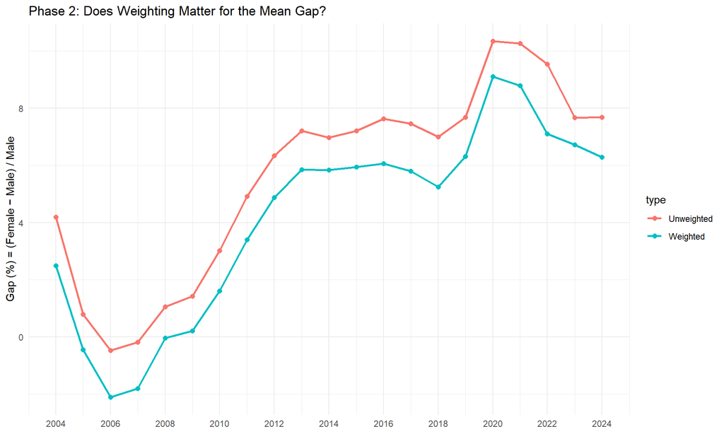

```r
phase2 <- lfs_analysis %>%
  group_by(year, sex_label) %>%
  summarize(uwt_mean = mean(real_basic_pay_php),
            wt_mean  = weighted.mean(real_basic_pay_php, w = weight)) %>%
  pivot_wider(names_from = sex_label, values_from = c(uwt_mean, wt_mean),
              names_glue = "{sex_label}_{.value}") %>%
  mutate(uwt_gap_pct = (Female_uwt_mean - Male_uwt_mean) / Male_uwt_mean * 100,
         wt_gap_pct  = (Female_wt_mean - Male_wt_mean) / Male_wt_mean * 100)

phase2 %>%
  select(year, Unweighted = uwt_gap_pct, Weighted = wt_gap_pct) %>%
  pivot_longer(-year, names_to = "type", values_to = "pct") %>%
  ggplot(aes(x = year, y = pct, color = type)) +
  geom_line(linewidth = 1) + geom_point(size = 2) +
  labs(x = NULL, y = "Gap (%) = (Female − Male) / Male",
       title = "Phase 2: Does Weighting Matter for the Mean Gap?") +
  scale_x_continuous(breaks = seq(2004, 2024, 2)) +
  theme_minimal()
```

**Insight:** The weighted and unweighted series track each other closely, suggesting the gender composition of the waged labor force does not vary dramatically across the strata corrected by LFS weights (region, urbanity). The survey design correction matters more for levels than for the gap itself. We proceed with weighted estimates from here on.

# Phase 3: Mean vs Median Gap

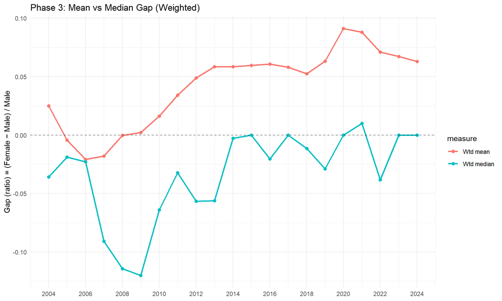

```r
phase3 <- lfs_analysis %>%
  group_by(year, sex_label) %>%
  summarize(wt_mean   = weighted.mean(real_basic_pay_php, w = weight),
            wt_median = weighted.median(real_basic_pay_php, w = weight)) %>%
  pivot_wider(names_from = sex_label, values_from = c(wt_mean, wt_median),
              names_glue = "{sex_label}_{.value}") %>%
  mutate(mean_gap_pct   = (Female_wt_mean - Male_wt_mean) / Male_wt_mean,
         median_gap_pct = (Female_wt_median - Male_wt_median) / Male_wt_median)

phase3 %>%
  select(year, `Wtd mean` = mean_gap_pct, `Wtd median` = median_gap_pct) %>%
  pivot_longer(-year, names_to = "measure", values_to = "pct") %>%
  ggplot(aes(x = year, y = pct, color = measure)) +
  geom_line(linewidth = 1) + geom_point(size = 2) +
  geom_hline(yintercept = 0, linetype = "dashed", alpha = 0.5) +
  labs(x = NULL, y = "Gap (ratio) = (Female − Male) / Male",
       title = "Phase 3: Mean vs Median Gap (Weighted)") +
  scale_x_continuous(breaks = seq(2004, 2024, 2)) +
  theme_minimal()
```

# Phase 4: Log Wage Gap

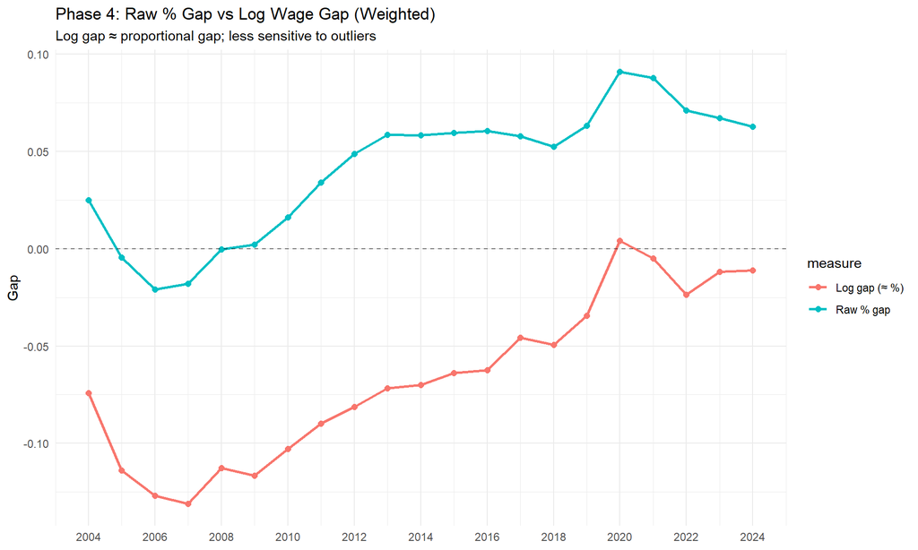

```r
phase4 <- lfs_analysis %>%
  group_by(year, sex_label) %>%
  summarize(wt_mean    = weighted.mean(real_basic_pay_php, w = weight),
            wt_mean_ln = weighted.mean(ln_wage, w = weight)) %>%
  pivot_wider(names_from = sex_label, values_from = c(wt_mean, wt_mean_ln),
              names_glue = "{sex_label}_{.value}") %>%
  mutate(raw_gap_pct = (Female_wt_mean - Male_wt_mean) / Male_wt_mean,
         gap_ln      = Female_wt_mean_ln - Male_wt_mean_ln)

phase4 %>%
  select(year, `Raw % gap` = raw_gap_pct, `Log gap (≈ %)` = gap_ln) %>%
  pivot_longer(-year, names_to = "measure", values_to = "value") %>%
  ggplot(aes(x = year, y = value, color = measure)) +
  geom_line(linewidth = 1) + geom_point(size = 2) +
  geom_hline(yintercept = 0, linetype = "dashed", alpha = 0.5) +
  labs(x = NULL, y = "Gap",
       title = "Phase 4: Raw % Gap vs Log Wage Gap (Weighted)",
       subtitle = "Log gap ≈ proportional gap; less sensitive to outliers") +
  scale_x_continuous(breaks = seq(2004, 2024, 2)) +
  theme_minimal()
```

# Phase 5: OLS — Adjusted Gap

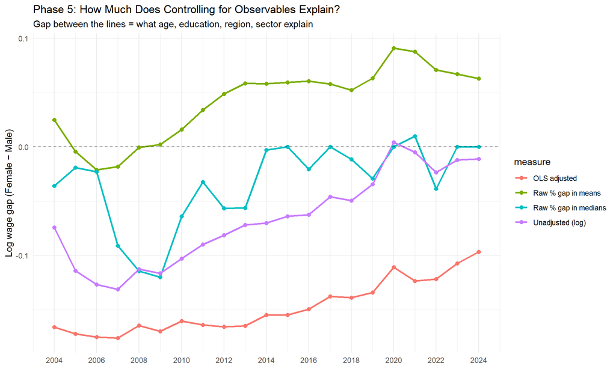

```r
fmla_ols <- ln_wage ~ female + age_years + age_sq + educ + region_cat + ind_label

# Cleaner extraction using map instead of for loop
phase5 <- tibble(year = 2004:2024) %>%
  mutate(
    ols_gap = map_dbl(year, ~ {
      lm(fmla_ols, data = lfs_analysis %>% filter(year == .x), weights = weight) %>%
        coef() %>% pluck("female")
    })
  ) %>%
  left_join(phase4 %>% select(year, gap_ln), by = "year") %>%
  left_join(phase3 %>% select(year, mean_gap_pct, median_gap_pct), by = "year")

phase5 %>%
  select(year,
         `Raw % gap in means`   = mean_gap_pct,
         `Raw % gap in medians` = median_gap_pct,
         `Unadjusted (log)`     = gap_ln,
         `OLS adjusted`         = ols_gap) %>%
  pivot_longer(-year, names_to = "measure", values_to = "value") %>%
  ggplot(aes(x = year, y = value, color = measure)) +
  geom_line(linewidth = 1) + geom_point(size = 2) +
  geom_hline(yintercept = 0, linetype = "dashed", alpha = 0.5) +
  labs(x = NULL, y = "Log wage gap (Female − Male)",
       title = "Phase 5: How Much Does Controlling for Observables Explain?",
       subtitle = "Gap between the lines = what age, education, region, sector explain") +
  scale_x_continuous(breaks = seq(2004, 2024, 2)) +
  theme_minimal()
```

# Phase 6: Oaxaca-Blinder Decomposition

## 6.1 From OLS to Oaxaca-Blinder: Why separate regressions?

In Phase 5, we estimated a single pooled regression:

$$\ln(w_i) = \alpha + \delta \cdot
\text{female}_i + X_i \beta + \varepsilon_i$$

where $\delta$ is the “adjusted gap” — a single intercept shift that forces the returns to all characteristics ($\beta$) to be identical for men and women. This is restrictive. If the return to a college degree is higher for men than for women (due to occupational sorting, glass ceilings, etc.), the pooled model can’t capture that — it averages the returns and dumps the residual into $\delta$.

Oaxaca-Blinder relaxes this by estimating **separate wage equations** for each group:

$$\text{Men:} \quad \ln(w_m) = X_m \beta_m
+ \varepsilon_m$$
$$\text{Women:}
\quad \ln(w_f) = X_f \beta_f + \varepsilon_f$$

This allows the returns ($\beta$) to differ by gender. The observed gap in mean log wages is then:

$$\Delta = \bar{X}_f \beta_f - \bar{X}_m
\beta_m$$

where $\bar{X}_g$ is the vector of mean characteristics for group $g$. Following our **(Female − Male)** sign convention, $\Delta > 0$ means women earn more and $\Delta < 0$ means men earn more. The decomposition’s job is to split $\Delta$ into an “explained” part (due to differences in characteristics) and an “unexplained” part (due to differences in returns).

## 6.2 Helper functions

We need two utility functions before running the decomposition.

**Weighted column means** computes $\bar{X}_g$ — the average “profile” of workers in group $g$ (mean age, share with college education, share in NCR, share in manufacturing, etc.), weighted by LFS survey weights. Without weighting, oversampled strata would distort the average profile.

```r
wtd_colmeans <- function(mod, w) {
  mm <- model.matrix(mod)  # design matrix X: one row per obs, one col per regressor
  colSums(mm * w) / sum(w) # weighted mean of each column → X̄
}
```

**Alignment function** ensures all coefficient and mean vectors are conformable. When we run separate regressions, the design matrices may differ — for example, if no women work in mining in a given year, the female regression won’t have an `ind_labelMining` coefficient, but the male regression will. We need all vectors ($\beta_m$, $\beta_f$, $\beta^*$, $\bar{X}_m$, $\bar{X}_f$) to share the same names and length for element-wise arithmetic. Missing coefficients are set to zero — equivalent to “this category has no effect in the regression that excludes it.”

```r
align_vec <- function(v, nms) {
  out <- set_names(rep(0, length(nms)), nms) # zero-filled vector with all names
  out[names(v)] <- v                          # overwrite with actual values
  out
}
```

## 6.3 Separate regressions by gender

The OB formula includes all covariates **except** the female dummy. Since we estimate separate regressions by group, gender is identified by *which regression* we’re in, not by a dummy variable.

```r
fmla_ob <- ln_wage ~ age_years + age_sq + educ + region_cat + ind_label
```

For each year, we estimate three weighted regressions and extract their coefficients and mean characteristics:

- **Male equation** ($\beta_m$): “How does the labor market reward men’s characteristics?” — e.g., what is the return to a college degree for men?
- **Female equation** ($\beta_f$): “How does the labor market reward women’s characteristics?” — if $\beta_f(\text{college}) < \beta_m(\text{college})$, women receive a lower return to college than men, evidence of within-education pay inequality.
- **Pooled equation** ($\beta^*$): “What would the returns be in a non-discriminatory labor market?” — needed for the Neumark reference wage structure (Section 6.5).

```r
phase6_raw <- tibble(year = 2004:2024) %>%
  mutate(
    components = map(year, \(y) {
      d <- lfs_analysis %>% filter(year == y)
      m <- d %>% filter(female == 0)
      f <- d %>% filter(female == 1)

      reg_m <- lm(fmla_ob, data = m, weights = weight)  # β_m: male returns
      reg_f <- lm(fmla_ob, data = f, weights = weight)  # β_f: female returns
      reg_p <- lm(fmla_ob, data = d, weights = weight)  # β*:  pooled returns

      # Union of all coef names so vectors are conformable
      all_nms <- Reduce(union, list(
        names(coef(reg_m)), names(coef(reg_f)), names(coef(reg_p))
      ))

      list(
        b_m = align_vec(coef(reg_m), all_nms),                    # β_m
        b_f = align_vec(coef(reg_f), all_nms),                    # β_f
        b_p = align_vec(coef(reg_p), all_nms),                    # β*
        x_m = align_vec(wtd_colmeans(reg_m, m$weight), all_nms),  # X̄_m
        x_f = align_vec(wtd_colmeans(reg_f, f$weight), all_nms)   # X̄_f
      )
    })
  )
```

## 6.4 Twofold decomposition (male reference)

The classic Oaxaca (1973) and Blinder (1973) decomposition adds and subtracts $\bar{X}_f \beta_m$ to split the gap into two components. Using our **(Female − Male)** convention:

$$\Delta = \underbrace{(\bar{X}_f -
\bar{X}_m) \beta_m}_{\text{Endowments (explained)}} +
\underbrace{\bar{X}_f (\beta_f - \beta_m)}_{\text{Coefficients
(unexplained)}}$$

- **Endowments** (explained): “How much of the gap is because men and women have different observable characteristics?” Evaluated at male returns $\beta_m$ — i.e., “If women had men’s age, education, region, and industry profile but were still paid at men’s rates, how much would the gap change?” **Positive = women have better endowments** (e.g., more education), which pushes wages in their favor.
- **Coefficients** (unexplained): “How much is because the labor market rewards the same characteristics differently by gender?” Evaluated at women’s characteristics $\bar{X}_f$ — i.e., “If women kept their own profile but received men’s returns, how much would they gain?” **Negative = women receive lower returns**, interpreted as an upper bound on discrimination (though it also captures unobserved productivity differences and misspecification).

This is called the “male-reference” decomposition because it uses $\beta_m$ as the counterfactual wage structure — implicitly assuming men are paid “correctly” and the entire coefficients effect reflects underpayment of women.

```r
phase6_male <- phase6_raw %>%
  mutate(
    # Total: X̄_f·β_f − X̄_m·β_m (should match gap_ln from Phase 4)
    ob_total = map_dbl(components, ~ sum(.x$x_f * .x$b_f) - sum(.x$x_m * .x$b_m)),
    # Endowments: (X̄_f − X̄_m)·β_m — gap due to different characteristics
    ob_endow = map_dbl(components, ~ sum((.x$x_f - .x$x_m) * .x$b_m)),
    # Coefficients: X̄_f·(β_f − β_m) — gap due to different returns
    ob_coeff = map_dbl(components, ~ sum(.x$x_f * (.x$b_f - .x$b_m)))
  )

phase6_male %>% select(year, ob_total, ob_endow, ob_coeff) %>% print(n = Inf)
```

```
## # A tibble: 21 × 4
##     year ob_total ob_endow ob_coeff
##    <int>    <dbl>    <dbl>    <dbl>
##  1  2004 -0.0740    0.104    -0.178
##  2  2005 -0.114     0.0701   -0.184
##  3  2006 -0.127     0.0533   -0.180
##  4  2007 -0.131     0.0529   -0.184
##  5  2008 -0.113     0.0660   -0.179
##  6  2009 -0.116     0.0605   -0.177
##  7  2010 -0.103     0.0596   -0.163
##  8  2011 -0.0898    0.0758   -0.166
##  9  2012 -0.0813    0.0793   -0.161
## 10  2013 -0.0718    0.0916   -0.163
## 11  2014 -0.0701    0.0838   -0.154
## 12  2015 -0.0639    0.0952   -0.159
## 13  2016 -0.0623    0.101    -0.163
## 14  2017 -0.0458    0.103    -0.149
## 15  2018 -0.0494    0.0996   -0.149
## 16  2019 -0.0344    0.109    -0.144
## 17  2020  0.00424   0.119    -0.115
## 18  2021 -0.00482   0.122    -0.127
## 19  2022 -0.0235    0.103    -0.127
## 20  2023 -0.0118    0.0978   -0.110
## 21  2024 -0.0110    0.0925   -0.104
```

**Verification:** `ob_total` should equal `ob_endow + ob_coeff` (up to rounding), and should match the weighted log gap from Phase 4. Under our sign convention: if `ob_total` ≈ negative, `ob_endow` ≈ positive, and `ob_coeff` ≈ negative, this confirms that women’s favorable characteristics (positive endowments) are masking a larger underlying returns penalty (negative coefficients).

## 6.5 Neumark (pooled) decomposition

The male-reference decomposition has a well-known **index number problem**: using $\beta_m$ as the “fair” benchmark assumes men are paid correctly and women are underpaid. But what if men are *overpaid* due to favoritism? The choice of reference group isn’t innocuous — using $\beta_f$ as the reference would give different endowments and coefficients values.

Neumark (1988) addresses this by using the pooled regression coefficients $\beta^*$ as the non-discriminatory counterfactual wage structure:

$$\Delta = \underbrace{(\bar{X}_f -
\bar{X}_m) \beta^*}_{\text{Endowments}} + \underbrace{\bar{X}_f (\beta_f
- \beta^*) + \bar{X}_m (\beta^* -
\beta_m)}_{\text{Coefficients}}$$

The coefficients term now has a natural interpretation in two parts:

- $\bar{X}_f (\beta_f - \beta^*)$: how much **women are underpaid** relative to the non-discriminatory norm (negative if $\beta_f < \beta^*$)
- $\bar{X}_m (\beta^* - \beta_m)$: how much **men are overpaid** relative to the norm, contributing negatively to the Female − Male gap (negative if $\beta_m > \beta^*$)

We report their sum as a single “coefficients” component. This is the default in most implementations of the `oaxaca` R package.

```r
phase6 <- phase6_male %>%
  mutate(
    # Endowments at pooled returns: (X̄_f − X̄_m)·β*
    ob_endow_neumark = map_dbl(components, ~ sum((.x$x_f - .x$x_m) * .x$b_p)),
    # Coefficients: female underpayment + male overpayment vs β*
    ob_coeff_neumark = map_dbl(components, ~ {
      sum(.x$x_f * (.x$b_f - .x$b_p)) + sum(.x$x_m * (.x$b_p - .x$b_m))
    })
  ) %>%
  select(year, ob_total, ob_endow, ob_coeff, ob_endow_neumark, ob_coeff_neumark)

phase6 %>% print(n = Inf)
```

```
## # A tibble: 21 × 6
##     year ob_total ob_endow ob_coeff ob_endow_neumark ob_coeff_neumark
##    <int>    <dbl>    <dbl>    <dbl>            <dbl>            <dbl>
##  1  2004 -0.0740    0.104    -0.178         0.0439            -0.118
##  2  2005 -0.114     0.0701   -0.184         0.0102            -0.124
##  3  2006 -0.127     0.0533   -0.180        -0.000166          -0.127
##  4  2007 -0.131     0.0529   -0.184        -0.00358           -0.128
##  5  2008 -0.113     0.0660   -0.179         0.00647           -0.119
##  6  2009 -0.116     0.0605   -0.177         0.00685           -0.123
##  7  2010 -0.103     0.0596   -0.163         0.0144            -0.117
##  8  2011 -0.0898    0.0758   -0.166         0.0308            -0.121
##  9  2012 -0.0813    0.0793   -0.161         0.0416            -0.123
## 10  2013 -0.0718    0.0916   -0.163         0.0517            -0.124
## 11  2014 -0.0701    0.0838   -0.154         0.0453            -0.115
## 12  2015 -0.0639    0.0952   -0.159         0.0516            -0.116
## 13  2016 -0.0623    0.101    -0.163         0.0490            -0.111
## 14  2017 -0.0458    0.103    -0.149         0.0567            -0.103
## 15  2018 -0.0494    0.0996   -0.149         0.0534            -0.103
## 16  2019 -0.0344    0.109    -0.144         0.0648            -0.0992
## 17  2020  0.00424   0.119    -0.115         0.0866            -0.0824
## 18  2021 -0.00482   0.122    -0.127         0.0867            -0.0915
## 19  2022 -0.0235    0.103    -0.127         0.0678            -0.0914
## 20  2023 -0.0118    0.0978   -0.110         0.0684            -0.0802
## 21  2024 -0.0110    0.0925   -0.104         0.0609            -0.0719
```

## 6.6 Results

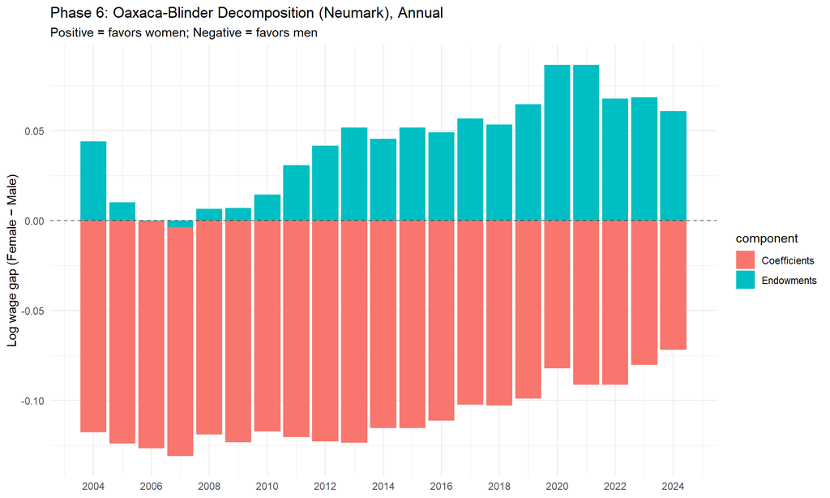

```r
phase6 %>%
  select(year, Endowments = ob_endow_neumark, Coefficients = ob_coeff_neumark) %>%
  pivot_longer(-year, names_to = "component", values_to = "value") %>%
  ggplot(aes(x = year, y = value, fill = component)) +
  geom_col(position = "stack") +
  geom_hline(yintercept = 0, linetype = "dashed", alpha = 0.5) +
  labs(x = NULL, y = "Log wage gap (Female − Male)",
       title = "Phase 6: Oaxaca-Blinder Decomposition (Neumark), Annual",
       subtitle = "Positive = favors women; Negative = favors men") +
  scale_x_continuous(breaks = seq(2004, 2024, 2)) +
  theme_minimal()
```

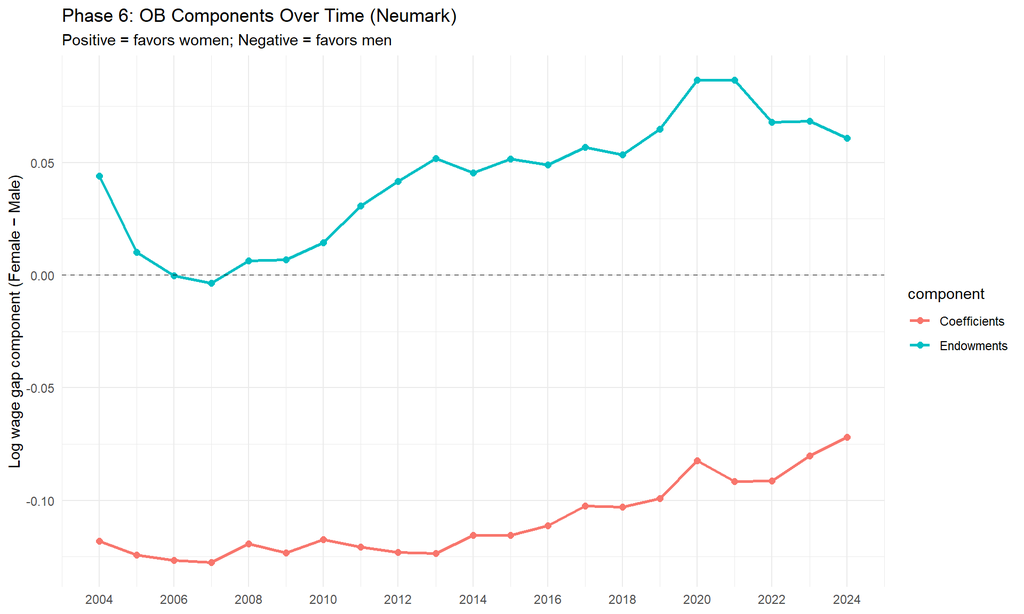

```r
phase6 %>%
  select(year, Endowments = ob_endow_neumark, Coefficients = ob_coeff_neumark) %>%
  pivot_longer(-year, names_to = "component", values_to = "value") %>%
  ggplot(aes(x = year, y = value, color = component)) +
  geom_line(linewidth = 1) + geom_point(size = 2) +
  geom_hline(yintercept = 0, linetype = "dashed", alpha = 0.5) +
  labs(x = NULL, y = "Log wage gap component (Female − Male)",
       title = "Phase 6: OB Components Over Time (Neumark)",
       subtitle = "Positive = favors women; Negative = favors men") +
  scale_x_continuous(breaks = seq(2004, 2024, 2)) +
  theme_minimal()
```

### Interpretation

**Magnitude of the coefficients effect — surprising.** Even in 2024, the coefficients component is approximately −0.07: women receive roughly 7% lower returns to the same characteristics than what a non-discriminatory benchmark would predict. Yet the total log gap is only about −0.01. This means the endowments advantage (+0.06) absorbs almost all of the returns penalty. Without women’s favorable sorting into education and higher-paying industries, the observed gender wage gap would be **six to seven times larger** than what raw log data shows. The raw gap is not just “partially explained” by composition — composition is doing nearly all the work of masking a substantial structural penalty.

**The endowments advantage is growing, not just the penalty shrinking.** The endowments component strengthens from roughly +0.01 in the mid-2000s to +0.06–0.09 by 2019–2024. Women’s compositional advantage has been expanding: they are increasingly more educated and better-sorted into higher-paying sectors relative to men. This means that the reason the raw gap has been “improving” (looking more favorable for women) is *not primarily* that discrimination is falling. It is substantially driven by women’s growing characteristics advantage outpacing a still-substantial returns penalty. The coefficients effect has been declining (from ~−0.13 to ~−0.07), which is genuine progress — but the endowments trend is doing at least as much of the heavy lifting in the raw numbers.

**COVID (2020) — a composition artifact.** 2020 is the year the total gap comes closest to zero. But this was not because the returns penalty vanished — the coefficients component declined only modestly. What surged was the endowments effect, reaching its most positive value (~+0.09). The likely explanation: COVID lockdowns disproportionately pushed lower-skilled women out of waged employment (services, retail, domestic work), leaving an even more positively selected female workforce. The apparent “improvement” in 2020 is a **composition artifact of crisis**, not genuine progress in labor market equality. By 2022–2024, the endowments effect partially reverts as those workers re-enter the workforce.

# Phase 7: Summary

```r
master <- phase2 %>%
  select(year, uwt_gap_pct, wt_gap_pct) %>%
  left_join(phase3 %>% select(year, wt_med_gap_pct = median_gap_pct), by = "year") %>%
  left_join(phase4 %>% select(year, gap_ln), by = "year") %>%
  left_join(phase5 %>% select(year, ols_gap), by = "year") %>%
  left_join(phase6 %>% select(year, ob_total, ob_endow_neumark, ob_coeff_neumark), by = "year")

master %>% print(n = Inf)
```

```
## # A tibble: 21 × 9
## # Groups:   year [21]
##     year uwt_gap_pct wt_gap_pct wt_med_gap_pct   gap_ln ols_gap ob_total
##    <int>       <dbl>      <dbl>          <dbl>    <dbl>   <dbl>    <dbl>
##  1  2004       4.20      2.49         -0.0357  -0.0740  -0.166  -0.0740
##  2  2005       0.788    -0.442        -0.0189  -0.114   -0.172  -0.114
##  3  2006      -0.470    -2.10         -0.0229  -0.127   -0.175  -0.127
##  4  2007      -0.182    -1.80         -0.0909  -0.131   -0.176  -0.131
##  5  2008       1.05     -0.0368       -0.114   -0.113   -0.164  -0.113
##  6  2009       1.43      0.219        -0.12    -0.116   -0.170  -0.116
##  7  2010       3.02      1.62         -0.0640  -0.103   -0.160  -0.103
##  8  2011       4.92      3.40         -0.0322  -0.0898  -0.164  -0.0898
##  9  2012       6.34      4.88         -0.0566  -0.0813  -0.166  -0.0813
## 10  2013       7.21      5.86         -0.0561  -0.0718  -0.165  -0.0718
## 11  2014       6.97      5.84         -0.00280 -0.0701  -0.155  -0.0701
## 12  2015       7.21      5.95          0       -0.0639  -0.155  -0.0639
## 13  2016       7.63      6.06         -0.0204  -0.0623  -0.149  -0.0623
## 14  2017       7.46      5.80          0       -0.0458  -0.138  -0.0458
## 15  2018       6.99      5.25         -0.0114  -0.0494  -0.139  -0.0494
## 16  2019       7.68      6.32         -0.0290  -0.0344  -0.134  -0.0344
## 17  2020      10.3       9.11          0        0.00424 -0.111   0.00424
## 18  2021      10.3       8.79          0.0100  -0.00482 -0.124  -0.00482
## 19  2022       9.54      7.11         -0.0384  -0.0235  -0.122  -0.0235
## 20  2023       7.66      6.72          0       -0.0118  -0.107  -0.0118
## 21  2024       7.68      6.29          0       -0.0110  -0.0966 -0.0110
## # ℹ 2 more variables: ob_endow_neumark <dbl>, ob_coeff_neumark <dbl>
```

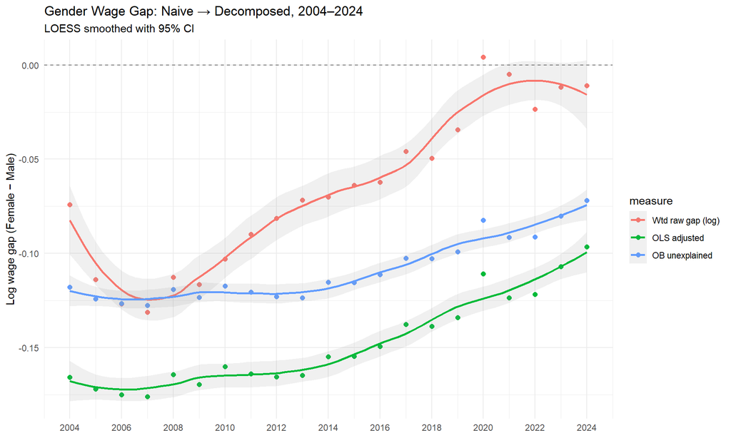

```r
master %>%
  select(year,
         `Wtd raw gap (log)` = gap_ln,
         `OLS adjusted`      = ols_gap,
         `OB unexplained`    = ob_coeff_neumark) %>%
  pivot_longer(-year, names_to = "measure", values_to = "value") %>%
  mutate(measure = fct_inorder(measure)) %>%
  ggplot(aes(x = year, y = value, color = measure)) +
  geom_point(size = 2) +
  geom_smooth(method = "loess", se = TRUE, span = 0.5, alpha = 0.15) +
  geom_hline(yintercept = 0, linetype = "dashed", alpha = 0.5) +
  labs(x = NULL, y = "Log wage gap (Female − Male)",
       title = "Gender Wage Gap: Naive → Decomposed, 2004–2024",
       subtitle = "LOESS smoothed with 95% CI") +
  scale_x_continuous(breaks = seq(2004, 2024, 2)) +
  theme_minimal()
```

```r
master %>%
  mutate(across(where(is.numeric) & !matches("year"), ~ round(.x, 4))) %>%
  knitr::kable(caption = "Summary: All Gap Measures by Year")
```

Summary: All Gap Measures by Year

| year | uwt_gap_pct | wt_gap_pct | wt_med_gap_pct | gap_ln | ols_gap | ob_total | ob_endow_neumark | ob_coeff_neumark |
| --- | --- | --- | --- | --- | --- | --- | --- | --- |
| 2004 | 4.1964 | 2.4916 | -0.0357 | -0.0740 | -0.1658 | -0.0740 | 0.0439 | -0.1179 |
| 2005 | 0.7882 | -0.4422 | -0.0189 | -0.1140 | -0.1720 | -0.1140 | 0.0102 | -0.1242 |
| 2006 | -0.4698 | -2.0975 | -0.0229 | -0.1268 | -0.1750 | -0.1268 | -0.0002 | -0.1267 |
| 2007 | -0.1822 | -1.8017 | -0.0909 | -0.1312 | -0.1761 | -0.1312 | -0.0036 | -0.1276 |
| 2008 | 1.0546 | -0.0368 | -0.1142 | -0.1126 | -0.1643 | -0.1126 | 0.0065 | -0.1191 |
| 2009 | 1.4301 | 0.2193 | -0.1200 | -0.1165 | -0.1697 | -0.1165 | 0.0069 | -0.1233 |
| 2010 | 3.0158 | 1.6165 | -0.0640 | -0.1030 | -0.1602 | -0.1030 | 0.0144 | -0.1174 |
| 2011 | 4.9227 | 3.4043 | -0.0322 | -0.0898 | -0.1639 | -0.0898 | 0.0308 | -0.1206 |
| 2012 | 6.3377 | 4.8760 | -0.0566 | -0.0813 | -0.1656 | -0.0813 | 0.0416 | -0.1229 |
| 2013 | 7.2051 | 5.8562 | -0.0561 | -0.0718 | -0.1649 | -0.0718 | 0.0517 | -0.1235 |
| 2014 | 6.9736 | 5.8365 | -0.0028 | -0.0701 | -0.1548 | -0.0701 | 0.0453 | -0.1154 |
| 2015 | 7.2145 | 5.9484 | 0.0000 | -0.0639 | -0.1547 | -0.0639 | 0.0516 | -0.1155 |
| 2016 | 7.6273 | 6.0603 | -0.0204 | -0.0623 | -0.1495 | -0.0623 | 0.0490 | -0.1113 |
| 2017 | 7.4569 | 5.7980 | 0.0000 | -0.0458 | -0.1377 | -0.0458 | 0.0567 | -0.1025 |
| 2018 | 6.9941 | 5.2460 | -0.0114 | -0.0494 | -0.1388 | -0.0494 | 0.0534 | -0.1028 |
| 2019 | 7.6824 | 6.3189 | -0.0290 | -0.0344 | -0.1341 | -0.0344 | 0.0648 | -0.0992 |
| 2020 | 10.3437 | 9.1110 | 0.0000 | 0.0042 | -0.1109 | 0.0042 | 0.0866 | -0.0824 |
| 2021 | 10.2658 | 8.7868 | 0.0100 | -0.0048 | -0.1236 | -0.0048 | 0.0867 | -0.0915 |
| 2022 | 9.5393 | 7.1082 | -0.0384 | -0.0235 | -0.1218 | -0.0235 | 0.0678 | -0.0914 |
| 2023 | 7.6646 | 6.7242 | 0.0000 | -0.0118 | -0.1071 | -0.0118 | 0.0684 | -0.0802 |
| 2024 | 7.6793 | 6.2889 | 0.0000 | -0.0110 | -0.0966 | -0.0110 | 0.0609 | -0.0719 |

### Key takeaways

The Philippine gender wage gap presents a **consistent paradox** across two decades of LFS data: